# WEIGHT LIFTING EXCERCISE DATA ANALYSIS

## ACCURACY EVALUATION ON THE VALIDATION SET AND BEST MODEL SELECTION

### Confusion matrix

Confusion matrix for each model will now be calculated on the validation set.

```r
cm_rf <- confusionMatrix(validation$classe, predict(rf, validation))
cm_knn <- confusionMatrix(validation$classe, predict(knn, validation))
cm_c5 <- confusionMatrix(validation$classe, predict(c5, validation))
cm_lda <- confusionMatrix(validation$classe, predict(lda, validation))
cm_qda <- confusionMatrix(validation$classe, predict(qda, validation))
cm_fda <- confusionMatrix(validation$classe, predict(fda, validation))
cm_GBM <- confusionMatrix(validation$classe, predict(GBM, validation))
```

While the graphic comparison of accuracy and confidence intervals of the 7 models will be performed in the next paragraph, the tabular version of all these confusion matrices can be found the Appendix 1.

### Plot of accuracies on validation set (which is equivalent to 1-Out of Sample Error)

In the following plot, accuracy on the validation set of each method will be displayed together with its confidence interval. The corresponding out of sample error is the complement to 1 of accuracy.

Two methods stands out from the rest and are virtually indistinguishable one other: Random Forest and C5 with an accuracy of 99,4% and a very narrow confidence interval. The corresponding Out of Sample Error is 0.6%.

Other 2 well performing techniques are the Knn and GBM with an accuracy of 96,6% and 95,8% respectively but a wider confidence interval with respect to RF and C5.

The discriminant analysis models performance are much worse with accuracies lower than 90%. The LDA is especially poor with an accuracy as low as 71,1%.

The fact that LDA performs much worse than QDA which in turns performs much worse than Knn confirms that this is a problem with highly non linear decision boundaries among classes.

```r
Models <- data.frame(
                    name=character(),
                    accuracy=numeric(),
                    lower=numeric(),
                    upper=numeric(),
                    system_time=numeric(),
                    user_time=numeric(),
                    elapsed_time=numeric(),
                    stringsAsFactors=FALSE
                    )

Models <- data.frame(name="Random forests", accuracy=cm_rf$overall[1], lower=cm_rf$overall[3], upper=cm_rf$overall[4], elapsed_time=rf_time[3], user_time=rf_time[1]+rf_time[4], system_time=rf_time[2]+rf_time[5])

Models <- rbind(Models, data.frame(name="KNN", accuracy=cm_knn$overall[1], lower=cm_knn$overall[3], upper=cm_knn$overall[4], elapsed_time=knn_time[3], user_time=knn_time[1]+knn_time[4], system_time=knn_time[2]+knn_time[5]))

Models <- rbind(Models, data.frame(name="C5", accuracy=cm_c5$overall[1], lower=cm_c5$overall[3], upper=cm_c5$overall[4], elapsed_time=c5_time[3], user_time=c5_time[1]+c5_time[4], system_time=c5_time[2]+c5_time[5]))

Models <- rbind(Models, data.frame(name="LDA", accuracy=cm_lda$overall[1], lower=cm_lda$overall[3], upper=cm_lda$overall[4], elapsed_time=LDA_time[3], user_time=LDA_time[1]+LDA_time[4], system_time=LDA_time[2]+LDA_time[5]))

Models <- rbind(Models, data.frame(name="QDA", accuracy=cm_qda$overall[1], lower=cm_qda$overall[3], upper=cm_qda$overall[4], elapsed_time=QDA_time[3], user_time=QDA_time[1]+QDA_time[4], system_time=QDA_time[2]+QDA_time[5]))

Models <- rbind(Models, data.frame(name="FDA", accuracy=cm_fda$overall[1], lower=cm_fda$overall[3], upper=cm_fda$overall[4], elapsed_time=FDA_time[3], user_time=FDA_time[1]+FDA_time[4], system_time=FDA_time[2]+FDA_time[5]))

Models <- rbind(Models, data.frame(name="GBM", accuracy=cm_GBM$overall[1], lower=cm_GBM$overall[3], upper=cm_GBM$overall[4], elapsed_time=GBM_time[3], user_time=GBM_time[1]+GBM_time[4], system_time=GBM_time[2]+GBM_time[5]))
```

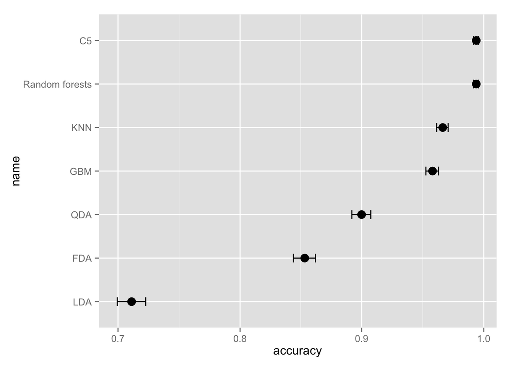

```r
Models <- Models[ order(Models[,2]), ]
ggplot(Models, aes(x=name, y=accuracy)) +
  geom_point(size=4) +
  geom_errorbar(aes(ymin=lower, ymax=upper), width=.2) +
  scale_x_discrete(limits=Models$name)+
  coord_flip()
```

### Plot of elapsed training time

In the graph below, the training elapsed time of each model will be plot versus the accuracy, so that in 1 single plot we have both the variables of interest for models comparison and evaluation.

Stretching this concept to an extreme, depending on how often the user is called to update the model building phase on (for instance on data set which may be updated frequently), one may also consider to use the Knn algorithm instead of C5 and Random Forest, because while not reaching the same accuracy (96,6% for the Knn and 99,4% for the C5 and Random Forest), Knn took only 1 minute and a half to train the data set while Random Forest took 1hr and 30 minutes and C5 approximately 23 minutes to perform the same task on the same dataset my computer.

```r
rf_time
```

```
##    user  system elapsed
## 5512.55   70.57 5596.21
```

```r
c5_time
```

```
##    user  system elapsed
## 1362.89   11.12 1387.40
```

```r
knn_time
```

```
##    user  system elapsed
##  86.570   3.946  90.515
```

```r
GBM_time
```

```
##    user  system elapsed
##  493.76    3.44  497.68
```

```r
QDA_time
```

```
##    user  system elapsed
##  14.494   1.874  16.369
```

```r
FDA_time
```

```
##    user  system elapsed
## 458.904   9.564 468.696
```

```r
LDA_time
```

```
##    user  system elapsed
##   16.02    2.06   18.53
```

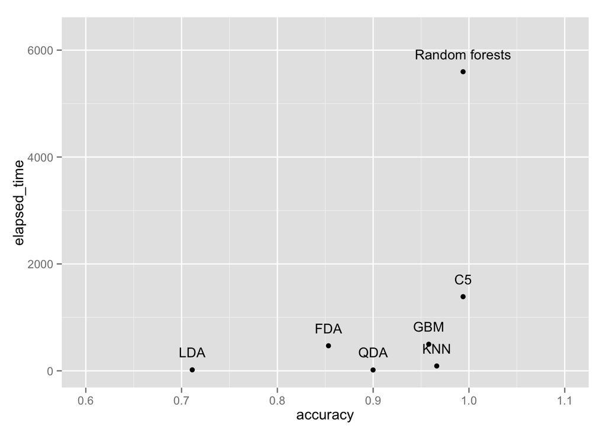

```r
ggplot(Models,aes(x=accuracy, y=elapsed_time)) + geom_point() + geom_text(aes(x=accuracy, label=name), size=4, vjust=-1.3)+ xlim(0.6, 1.1)+ ylim(0, 6300)
```

## PERFORMANCE ON THE TEST DATA

As last step in this project, I would like to compare performance of Random Forest, C5 and Knn models, i.e the top 3 performing algorithms, on the 20 row data set provided in the project. Comparison will be performed both in terms of accuracy and in terms of testing elapsed time. Please notice that in this case, the elapsed time being considered is NOT the time to build the model (as above) but the time needed to make 20 predictions using already available models (built above).

This test data will be used only once and, regardless the output, the models built will NOT be changed since otherwise this test set would become part of the training set.

Before running the code, and before seeing the output I anticipate my expectations: if my analysis above is correct, I would expect the RF and C5 models giving the exact same output. I would expect also Knn to give the exact same result (Knn accuracy is not as good as C5 but it is still very high) even though I would not be surprised for a few discrepancies.

Finally I would also expect Knn testing time to be much lower than Random Forest and C5.

```r
testingData  <- read.csv("pml-testing.csv", header = TRUE)
suppressWarnings(for (i in 1:(ncol(testingData )-1)) testingData [,i] <- as.numeric(as.character(testingData [,i])))

ptm <- proc.time()
test_rf <- predict(rf, newdata = testingData)
rf_test_time<- proc.time() - ptm

ptm <- proc.time()
test_c5 <- predict(c5, newdata = testingData)
c5_test_time<- proc.time() - ptm

ptm <- proc.time()
test_knn <- predict(knn, newdata = testingData)
knn_test_time<- proc.time() - ptm


test_rf
```

```
##  [1] B A B A A E D B A A B C B A E E A B B B
## Levels: A B C D E
```

```r
test_c5
```

```
##  [1] B A B A A E D B A A B C B A E E A B B B
## Levels: A B C D E
```

```r
test_knn
```

```
##  [1] B A A A A E D B A A B C B A E E A B B B
## Levels: A B C D E
```

```r
# Generate the 20 txt files with the 20 predictions to be submitted through the Coursera web page.
# Please notice that these prediction has been generated through c5, i.e. the best model chosen for this data set.

  n = length(test_c5)
  for(i in 1:n){
    filename = paste0("problem_id_",i,".txt")
    write.table(test_c5[i],file=filename,quote=FALSE,row.names=FALSE,col.names=FALSE)
  }
```

Let’s count the output difference between RF/C5 and between C5/Knn.  
Number of different predicted cases between RF and C5:

```r
sum(!(test_rf==test_c5))
```

```
## [1] 0
```

Number of different predicted cases between C5 and Knn:

```r
sum(!(test_knn==test_c5))
```

```
## [1] 1
```

Differences in testing time:

```r
rf_test_time
```

```
##    user  system elapsed
##   7.992   2.192  10.184
```

```r
c5_test_time
```

```
##    user  system elapsed
##   0.351   0.077   0.427
```

```r
knn_test_time
```

```
##    user  system elapsed
##   0.116   0.015   0.131
```

```r
rf_c5_ratio <- rf_test_time[3]/c5_test_time[3]
c5_knn_ratio <-  c5_test_time[3]/knn_test_time[3]
```

C5 was 23.8501 faster than RF in making predictions.  
Knn was 3.2595 faster than C5 in making predictions.

In contrast with the expectations, Knn produced 1 prediction different than the other 2 models.  
On the other hand, as expected, Knn was the fastest model to perform the predictions.

## CONCLUSIONS

Knn may become a excellent alternative if training elapsed time is a concern: giving up for a few points in accuracy, substantial gaining in training and testing processing times can be achieved.

## APPENDIX 1: CONFUSION MATRIX OF EACH OF THE 7 CONSIDERED MODELS

```r
cm_rf
```

```
## Confusion Matrix and Statistics
##
##           Reference
## Prediction    A    B    C    D    E
##          A 1673    1    0    0    0
##          B    1 1135    3    0    0
##          C    0    4 1018    4    0
##          D    0    0   16  947    1
##          E    0    0    4    2 1076
##
## Overall Statistics
##
##                Accuracy : 0.994
##                  95% CI : (0.992, 0.996)
##     No Information Rate : 0.284
##     P-Value [Acc > NIR] : <2e-16
##
##                   Kappa : 0.992
##  Mcnemar's Test P-Value : NA
##
## Statistics by Class:
##
##                      Class: A Class: B Class: C Class: D Class: E
## Sensitivity             0.999    0.996    0.978    0.994    0.999
## Specificity             1.000    0.999    0.998    0.997    0.999
## Pos Pred Value          0.999    0.996    0.992    0.982    0.994
## Neg Pred Value          1.000    0.999    0.995    0.999    1.000
## Prevalence              0.284    0.194    0.177    0.162    0.183
## Detection Rate          0.284    0.193    0.173    0.161    0.183
## Detection Prevalence    0.284    0.194    0.174    0.164    0.184
## Balanced Accuracy       1.000    0.997    0.988    0.995    0.999
```

```r
cm_c5
```

```
## Confusion Matrix and Statistics
##
##           Reference
## Prediction    A    B    C    D    E
##          A 1673    1    0    0    0
##          B    1 1135    3    0    0
##          C    0    4 1018    4    0
##          D    0    0   16  947    1
##          E    0    0    4    2 1076
##
## Overall Statistics
##
##                Accuracy : 0.994
##                  95% CI : (0.992, 0.996)
##     No Information Rate : 0.284
##     P-Value [Acc > NIR] : <2e-16
##
##                   Kappa : 0.992
##  Mcnemar's Test P-Value : NA
##
## Statistics by Class:
##
##                      Class: A Class: B Class: C Class: D Class: E
## Sensitivity             0.999    0.996    0.978    0.994    0.999
## Specificity             1.000    0.999    0.998    0.997    0.999
## Pos Pred Value          0.999    0.996    0.992    0.982    0.994
## Neg Pred Value          1.000    0.999    0.995    0.999    1.000
## Prevalence              0.284    0.194    0.177    0.162    0.183
## Detection Rate          0.284    0.193    0.173    0.161    0.183
## Detection Prevalence    0.284    0.194    0.174    0.164    0.184
## Balanced Accuracy       1.000    0.997    0.988    0.995    0.999
```

```r
cm_knn
```

```
## Confusion Matrix and Statistics
##
##           Reference
## Prediction    A    B    C    D    E
##          A 1652   16    2    3    1
##          B   29 1080   24    6    0
##          C    2   17  987   12    8
##          D    6    0   38  916    4
##          E    1    9   11    9 1052
##
## Overall Statistics
##
##                Accuracy : 0.966
##                  95% CI : (0.961, 0.971)
##     No Information Rate : 0.287
##     P-Value [Acc > NIR] : < 2e-16
##
##                   Kappa : 0.957
##  Mcnemar's Test P-Value : 5.97e-05
##
## Statistics by Class:
##
##                      Class: A Class: B Class: C Class: D Class: E
## Sensitivity             0.978    0.963    0.929    0.968    0.988
## Specificity             0.995    0.988    0.992    0.990    0.994
## Pos Pred Value          0.987    0.948    0.962    0.950    0.972
## Neg Pred Value          0.991    0.991    0.985    0.994    0.997
## Prevalence              0.287    0.191    0.180    0.161    0.181
## Detection Rate          0.281    0.184    0.168    0.156    0.179
## Detection Prevalence    0.284    0.194    0.174    0.164    0.184
## Balanced Accuracy       0.986    0.975    0.961    0.979    0.991
```

```r
cm_lda
```

```
## Confusion Matrix and Statistics
##
##           Reference
## Prediction    A    B    C    D    E
##          A 1375   36  131  126    6
##          B  180  757  111   43   48
##          C  106  106  665  128   21
##          D   65   38  114  712   35
##          E   47  179   81   99  676
##
## Overall Statistics
##
##                Accuracy : 0.711
##                  95% CI : (0.699, 0.723)
##     No Information Rate : 0.301
##     P-Value [Acc > NIR] : <2e-16
##
##                   Kappa : 0.634
##  Mcnemar's Test P-Value : <2e-16
##
## Statistics by Class:
##
##                      Class: A Class: B Class: C Class: D Class: E
## Sensitivity             0.776    0.678    0.603    0.643    0.860
## Specificity             0.927    0.920    0.925    0.947    0.920
## Pos Pred Value          0.821    0.665    0.648    0.739    0.625
## Neg Pred Value          0.905    0.924    0.910    0.920    0.977
## Prevalence              0.301    0.190    0.187    0.188    0.134
## Detection Rate          0.234    0.129    0.113    0.121    0.115
## Detection Prevalence    0.284    0.194    0.174    0.164    0.184
## Balanced Accuracy       0.851    0.799    0.764    0.795    0.890
```

```r
cm_qda
```

```
## Confusion Matrix and Statistics
##
##           Reference
## Prediction    A    B    C    D    E
##          A 1553   70   28   20    3
##          B   67  964   99    1    8
##          C    0   58  963    5    0
##          D    1    3  117  828   15
##          E    2   24   42   26  988
##
## Overall Statistics
##
##                Accuracy : 0.9
##                  95% CI : (0.892, 0.907)
##     No Information Rate : 0.276
##     P-Value [Acc > NIR] : <2e-16
##
##                   Kappa : 0.874
##  Mcnemar's Test P-Value : <2e-16
##
## Statistics by Class:
##
##                      Class: A Class: B Class: C Class: D Class: E
## Sensitivity             0.957    0.861    0.771    0.941    0.974
## Specificity             0.972    0.963    0.986    0.973    0.981
## Pos Pred Value          0.928    0.846    0.939    0.859    0.913
## Neg Pred Value          0.983    0.967    0.941    0.989    0.995
## Prevalence              0.276    0.190    0.212    0.150    0.172
## Detection Rate          0.264    0.164    0.164    0.141    0.168
## Detection Prevalence    0.284    0.194    0.174    0.164    0.184
## Balanced Accuracy       0.964    0.912    0.879    0.957    0.978
```

```r
cm_fda
```

```
## Confusion Matrix and Statistics
##
##           Reference
## Prediction    A    B    C    D    E
##          A 1534   60   53   27    0
##          B   70  929  110   22    8
##          C    1   92  865   67    1
##          D   18   17  105  804   20
##          E    8   72   59   53  890
##
## Overall Statistics
##
##                Accuracy : 0.853
##                  95% CI : (0.844, 0.862)
##     No Information Rate : 0.277
##     P-Value [Acc > NIR] : <2e-16
##
##                   Kappa : 0.815
##  Mcnemar's Test P-Value : <2e-16
##
## Statistics by Class:
##
##                      Class: A Class: B Class: C Class: D Class: E
## Sensitivity             0.941    0.794    0.726    0.826    0.968
## Specificity             0.967    0.955    0.966    0.967    0.961
## Pos Pred Value          0.916    0.816    0.843    0.834    0.823
## Neg Pred Value          0.977    0.949    0.933    0.966    0.994
## Prevalence              0.277    0.199    0.203    0.165    0.156
## Detection Rate          0.261    0.158    0.147    0.137    0.151
## Detection Prevalence    0.284    0.194    0.174    0.164    0.184
## Balanced Accuracy       0.954    0.875    0.846    0.897    0.965
```

```r
cm_GBM
```

```
## Confusion Matrix and Statistics
##
##           Reference
## Prediction    A    B    C    D    E
##          A 1643   23    2    4    2
##          B   32 1073   31    0    3
##          C    0   33  979   10    4
##          D    2    4   42  907    9
##          E    1   15   12   18 1036
##
## Overall Statistics
##
##                Accuracy : 0.958
##                  95% CI : (0.953, 0.963)
##     No Information Rate : 0.285
##     P-Value [Acc > NIR] : < 2e-16
##
##                   Kappa : 0.947
##  Mcnemar's Test P-Value : 4.53e-06
##
## Statistics by Class:
##
##                      Class: A Class: B Class: C Class: D Class: E
## Sensitivity             0.979    0.935    0.918    0.966    0.983
## Specificity             0.993    0.986    0.990    0.988    0.990
## Pos Pred Value          0.981    0.942    0.954    0.941    0.957
## Neg Pred Value          0.992    0.984    0.982    0.993    0.996
## Prevalence              0.285    0.195    0.181    0.160    0.179
## Detection Rate          0.279    0.182    0.166    0.154    0.176
## Detection Prevalence    0.284    0.194    0.174    0.164    0.184
## Balanced Accuracy       0.986    0.960    0.954    0.977    0.987
```